# Weekend-Weekday Offer-Price Differences by Room Type

STA302 Part 1: Preliminary multiple linear regression

November 5, 2026

# 1 Scope and research question

Across the ten sampled European cities, does the covariate-adjusted difference between weekend and weekday offer prices differ between entire homes/apartments and private rooms? The response, `realSum`, is the total advertised EUR price for **two guests and two nights**, including the fees described by the original authors. It is not a nightly price, completed transaction, or revenue measure.

This analysis implements the selected `research_plan.md`. It completes the preliminary-model component of Part 1: preparation, summaries, estimation, uncertainty, interpretation, and residual diagnostics. It is an analysis companion, not the word-limited proposal or complete submission package. Literature novelty, exact collection dates, course-specific ethics material, member contributions, and the teamwork agreement still require separate completion.

Offers are unmatched across day types. Adjustment describes observed associations and does not identify a within-property change or a causal weekend effect. All model terms were specified before this fit; there is no significance screening. Assumption repairs are reserved for later work, as required for Part 1.

# 2 Data import, coding, and validation

Table 1. Analytical-sample flow. No observations are removed for missingness or price extremes.

| Stage | Count |
| --- | --- |
| Imported offers | 51707 |
| Shared rooms excluded | 366 |
| Retained offers | 51341 |
| Missing model-variable entries | 0 |

All 20 original CSVs are read without modification. File names supply `city` and `day_type`; the exported row index is renamed `source_row_index` and retained for provenance only. Neither it nor `analysis_row` is a property or host identifier. The 366 shared-room offers are excluded to define the prespecified two-room-type target. The retained sample contains **51,341 offers**; all 40 city/day/room cells are populated (minimum cell size 180). No model-variable values are missing or nonfinite. Range checks are basic coding checks, not proof of accuracy. Zero bedrooms are retained as the studio encoding.

The mutually exclusive `multi` and `biz` indicators form `host_portfolio`: 0/0 = Single offer, 1/0 = 2-4 offers, 0/1 = 5+ offers. This is an operation-scale proxy, not verified business status. Boolean case is normalized before coding. Redundant room indicators, raw/normalized duplicates of attraction indices, and the original portfolio flags are excluded from the model.

Table 2. Offers in every city/day/room cell; these counts do not establish unique properties.

| City | Private: weekday | Private: weekend | Entire: weekday | Entire: weekend |
| --- | --- | --- | --- | --- |
| amsterdam | 559 | 385 | 538 | 588 |
| athens | 201 | 196 | 2447 | 2425 |
| barcelona | 1185 | 1094 | 362 | 180 |
| berlin | 775 | 754 | 474 | 408 |
| budapest | 216 | 203 | 1851 | 1738 |
| lisbon | 894 | 917 | 1928 | 1950 |
| london | 2625 | 2934 | 1966 | 2418 |
| paris | 758 | 769 | 2325 | 2742 |
| rome | 1731 | 1723 | 2754 | 2807 |
| vienna | 382 | 392 | 1349 | 1398 |

# 3 Numerical summaries and descriptive patterns

Table 3. The response and all 12 main predictors in the retained sample. Factor percentages use all 51,341 offers. Price is EUR for two guests/two nights; distances are km. The maximum price and mean-median gap show a long upper tail; zero bedrooms are retained.

| Variable | Level | n | Percent | Missing | Mean | SD | Min | Q1 | Median | Q3 | Max |
| --- | --- | --- | --- | --- | --- | --- | --- | --- | --- | --- | --- |
| realSum | Numeric | 51341 |  | 0 | 280.85 | 328.84 | 34.78 | 149.86 | 212.23 | 320.81 | 18545.45 |
| person_capacity | Numeric | 51341 |  | 0 | 3.16 | 1.30 | 2.00 | 2.00 | 3.00 | 4.00 | 6.00 |
| bedrooms | Numeric | 51341 |  | 0 | 1.16 | 0.63 | 0.00 | 1.00 | 1.00 | 1.00 | 10.00 |
| cleanliness_rating | Numeric | 51341 |  | 0 | 9.39 | 0.95 | 2.00 | 9.00 | 10.00 | 10.00 | 10.00 |
| guest_satisfaction_overall | Numeric | 51341 |  | 0 | 92.65 | 8.93 | 20.00 | 90.00 | 95.00 | 99.00 | 100.00 |
| dist | Numeric | 51341 |  | 0 | 3.19 | 2.39 | 0.02 | 1.45 | 2.61 | 4.26 | 25.28 |
| metro_dist | Numeric | 51341 |  | 0 | 0.68 | 0.86 | 0.00 | 0.25 | 0.41 | 0.74 | 14.27 |
| attr_index_norm | Numeric | 51341 |  | 0 | 13.43 | 9.81 | 0.93 | 6.38 | 11.47 | 17.41 | 100.00 |
| city | amsterdam | 2070 | 4.03 | 0 |  |  |  |  |  |  |  |
| city | athens | 5269 | 10.26 | 0 |  |  |  |  |  |  |  |
| city | barcelona | 2821 | 5.49 | 0 |  |  |  |  |  |  |  |
| city | berlin | 2411 | 4.70 | 0 |  |  |  |  |  |  |  |
| city | budapest | 4008 | 7.81 | 0 |  |  |  |  |  |  |  |
| city | lisbon | 5689 | 11.08 | 0 |  |  |  |  |  |  |  |
| city | london | 9943 | 19.37 | 0 |  |  |  |  |  |  |  |
| city | paris | 6594 | 12.84 | 0 |  |  |  |  |  |  |  |
| city | rome | 9015 | 17.56 | 0 |  |  |  |  |  |  |  |
| city | vienna | 3521 | 6.86 | 0 |  |  |  |  |  |  |  |
| day_type | weekdays | 25320 | 49.32 | 0 |  |  |  |  |  |  |  |
| day_type | weekends | 26021 | 50.68 | 0 |  |  |  |  |  |  |  |
| room_type | Private room | 18693 | 36.41 | 0 |  |  |  |  |  |  |  |
| room_type | Entire home/apt | 32648 | 63.59 | 0 |  |  |  |  |  |  |  |
| host_is_superhost | Non-Superhost | 38150 | 74.31 | 0 |  |  |  |  |  |  |  |
| host_is_superhost | Superhost | 13191 | 25.69 | 0 |  |  |  |  |  |  |  |
| host_portfolio | Single offer | 18463 | 35.96 | 0 |  |  |  |  |  |  |  |
| host_portfolio | 2-4 offers | 14990 | 29.20 | 0 |  |  |  |  |  |  |  |
| host_portfolio | 5+ offers | 17888 | 34.84 | 0 |  |  |  |  |  |  |  |

The mean price is EUR 280.85, the median is EUR 212.23, and the maximum is EUR 18,545.45. The long right tail motivates conditional residual and influence checks; a skewed marginal response alone does not establish a regression-assumption violation. `person_capacity` is maximum capacity, not the two guests used in the search. `attr_index_norm` measures relative within-city attraction accessibility; its units are not an absolute common attraction scale across cities.

Table 4. Day/room sample composition: numerical means and host-category percentages. These pooled summaries can also reflect city composition.

| day_type | room_type | n | capacity_mean | bedrooms_mean | cleanliness_mean | satisfaction_mean | dist_mean | metro_mean | attraction_mean | superhost_pct | single_pct | two_four_pct | five_plus_pct |
| --- | --- | --- | --- | --- | --- | --- | --- | --- | --- | --- | --- | --- | --- |
| weekdays | Private room | 9326 | 2.30 | 1.03 | 9.35 | 92.18 | 3.83 | 0.79 | 13.63 | 22.97 | 29.72 | 37.45 | 32.82 |
| weekends | Private room | 9367 | 2.30 | 1.03 | 9.36 | 92.28 | 3.91 | 0.81 | 13.98 | 22.47 | 30.51 | 37.37 | 32.12 |
| weekdays | Entire home/apt | 15994 | 3.68 | 1.25 | 9.42 | 92.86 | 2.76 | 0.62 | 13.06 | 27.70 | 37.88 | 24.75 | 37.37 |
| weekends | Entire home/apt | 16654 | 3.62 | 1.22 | 9.42 | 92.92 | 2.83 | 0.61 | 13.36 | 27.10 | 40.68 | 24.25 | 35.07 |

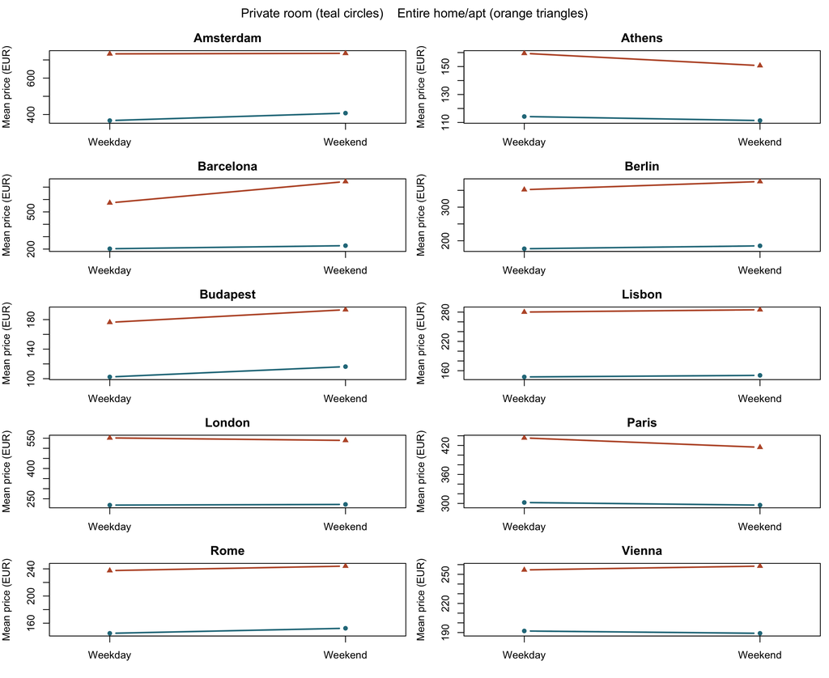

Figure 1. Observed mean two-night offer prices by city, day type, and room type. Lines join unmatched sample means, not repeated-property prices; these are unadjusted summaries.

# 4 Prespecified regression and estimand

Let $W=1$ denote weekends and $R=1$ denote Entire home/apt. The fitted mean is

$$E(P\mid c,W,R,X)=\alpha_c+\tau_c W+\rho_c R+\delta WR+\beta^\top X.$$

City-specific weekend baselines and city-specific room-type gaps are allowed. The central interaction $\delta$ is constrained to be the same across cities; all remaining covariate slopes are also pooled. No three-way interaction is fitted. These are substantive modeling assumptions, not consequences of city adjustment.

The private-room adjusted weekend-weekday difference in city $c$ is $\tau_c$; the entire-home difference is $\tau_c+\delta$. Therefore,

$$\delta=\Delta_{c,\mathrm{Entire}}-\Delta_{c,\mathrm{Private}},\qquad H_0:\delta=0.$$

Linear regression directly estimates adjusted **conditional mean EUR differences** and their interaction while accounting for several observed characteristics. A pooled two-sample comparison would not provide the same adjustment or direct test. The full specification contains 12 distinct main predictors, categorical and numerical predictors, and the required categorical interactions. Factor dummy columns are not counted as distinct predictors.

```r
model_formula <- realSum ~
  city * day_type + city * room_type + day_type * room_type +
  person_capacity + bedrooms + cleanliness_rating +
  guest_satisfaction_overall + host_is_superhost +
  dist + metro_dist + attr_index_norm + host_portfolio

# All formula variables are data columns; avoid saving the report's entire environment.
environment(model_formula) <- baseenv()
fit <- lm(model_formula, data = dat, na.action = na.fail, model = TRUE)
X <- model.matrix(fit)
stopifnot(nobs(fit) == nrow(dat), length(predictors) == 12L,
          ncol(X) == 41L, fit$rank == 41L, all(is.finite(X)), !anyNA(coef(fit)))
reduced <- update(fit, . ~ . - day_type:room_type)
stopifnot(identical(rownames(model.frame(fit)), rownames(model.frame(reduced))),
          nobs(reduced) == nobs(fit), reduced$rank == fit$rank - 1L)
sm <- summary(fit)
V <- vcov(fit)
ci <- confint(fit)
coefficient_table <- data.frame(term = rownames(sm$coefficients),
  estimate = sm$coefficients[, 1], SE = sm$coefficients[, 2],
  CI_low = ci[, 1], CI_high = ci[, 2], t = sm$coefficients[, 3],
  p = sm$coefficients[, 4], row.names = NULL)
core_term <- "day_typeweekends:room_typeEntire home/apt"
stopifnot(core_term %in% names(coef(fit)))
core <- coefficient_table[coefficient_table$term == core_term, ]
partial <- anova(reduced, fit)
stopifnot(isTRUE(all.equal(unname(partial$F[2]), unname(core$t^2), tolerance = 1e-7)))
fit_statistics <- data.frame(n = nobs(fit), coefficients = fit$rank,
  residual_df = df.residual(fit), R_squared = sm$r.squared,
  adjusted_R_squared = sm$adj.r.squared, residual_SD_EUR = sm$sigma,
  RMSE_in_sample_EUR = sqrt(mean(residuals(fit)^2)))
export(coefficient_table, "coefficients")
export(core, "primary_interaction")
export(data.frame(comparison = c("Reduced: no day/room interaction", "Full: prespecified"), partial,
                  row.names = NULL, check.names = FALSE), "partial_F_test")
export(fit_statistics, "fit_statistics")
saveRDS(fit, file.path(out_dir, "preliminary_model.rds"))
```

Reference levels are **Amsterdam**, **weekdays**, **Private room**, **Non-Superhost**, and **Single offer**. The intercept refers to these factor levels and all numerical predictors equal to zero; this is outside the observed capacity range, so the intercept has no useful standalone substantive interpretation.

Table 5. Preliminary OLS fit. R-squared is descriptive in-sample fit, not validation of assumptions or predictive accuracy.

| n | coefficients | residual_df | R_squared | adjusted_R_squared | residual_SD_EUR | RMSE_in_sample_EUR |
| --- | --- | --- | --- | --- | --- | --- |
| 51341 | 41 | 51300 | 0.261 | 0.261 | 282.726 | 282.613 |

Table 6. Primary interaction: entire-home minus private-room adjusted weekend-weekday difference (EUR). Classical OLS uncertainty is provisional.

| term | estimate | SE | CI_low | CI_high | t | p |
| --- | --- | --- | --- | --- | --- | --- |
| day_typeweekends:room_typeEntire home/apt | 3.8814 | 5.7208 | -7.3314 | 15.0942 | 0.6785 | 0.497 |

The core contrast is **EUR 3.88** (SE 5.72; conventional 95% CI [-7.33, 15.09]; $t$ = 0.68, $p$ = 0.497). A positive estimate means a more positive weekend-weekday difference for entire homes than for private rooms. It does not imply that either room type has a positive weekend-weekday difference in every city.

Under the conventional OLS test, there is insufficient evidence that the adjusted weekend-weekday difference varies by room type. This does **not** establish equal contrasts: the interval allows both negative and positive EUR differences.

Removing **only** `day_type:room_type`, on the same observations and with all other terms retained, gives a one-degree-of-freedom partial $F$ statistic of 0.460 ($p$ = 0.497). The code verifies $F=t^2$. This tests the prespecified contrast, not model selection. The diagnostics below qualify the conventional uncertainty and any significance claim.

## 4.1 Adjusted city-specific contrasts

Each contrast is computed from model-matrix row differences with variance $L\widehat{\operatorname{Var}}(\hat\beta)L^\top$, including all covariance terms. Other covariates are held equal and cancel algebraically; the arbitrary starting row does not set the target population. The 20 intervals are pointwise, not simultaneous. No cross-city aggregation weights are needed because each city is shown separately. The common gap between the two room-type contrasts is imposed by the model.

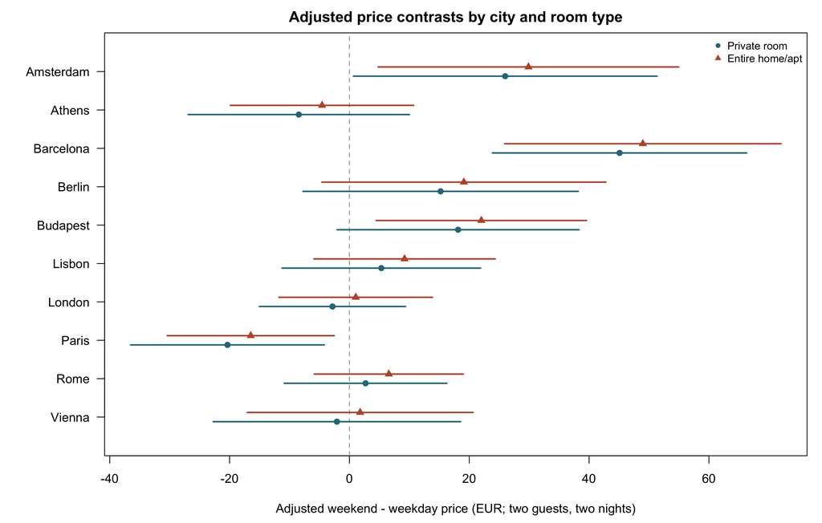

Figure 2. Adjusted weekend minus weekday offer-price differences, with pointwise classical 95% CIs. The entire-minus-private gap is pooled across cities; possible heteroskedasticity and dependence make uncertainty provisional.

Table 7. Adjusted city/room contrasts in EUR; full-covariance, pointwise classical intervals.

| city | room_type | estimate | SE | CI_low | CI_high |
| --- | --- | --- | --- | --- | --- |
| amsterdam | Private room | 26.00 | 12.92 | 0.67 | 51.33 |
| amsterdam | Entire home/apt | 29.88 | 12.79 | 4.81 | 54.96 |
| athens | Private room | -8.45 | 9.42 | -26.91 | 10.01 |
| athens | Entire home/apt | -4.57 | 7.80 | -19.86 | 10.72 |
| barcelona | Private room | 45.09 | 10.82 | 23.87 | 66.30 |
| barcelona | Entire home/apt | 48.97 | 11.77 | 25.90 | 72.04 |
| berlin | Private room | 15.22 | 11.72 | -7.75 | 38.18 |
| berlin | Entire home/apt | 19.10 | 12.09 | -4.60 | 42.79 |
| budapest | Private room | 18.14 | 10.30 | -2.05 | 38.33 |
| budapest | Entire home/apt | 22.02 | 8.96 | 4.46 | 39.58 |
| lisbon | Private room | 5.32 | 8.45 | -11.24 | 21.88 |
| lisbon | Entire home/apt | 9.20 | 7.72 | -5.92 | 24.33 |
| london | Private room | -2.83 | 6.22 | -15.02 | 9.37 |
| london | Entire home/apt | 1.05 | 6.54 | -11.76 | 13.87 |
| paris | Private room | -20.35 | 8.25 | -36.51 | -4.19 |
| paris | Entire home/apt | -16.47 | 7.11 | -30.40 | -2.54 |
| rome | Private room | 2.69 | 6.92 | -10.88 | 16.26 |
| rome | Entire home/apt | 6.57 | 6.35 | -5.87 | 19.01 |
| vienna | Private room | -2.09 | 10.52 | -22.72 | 18.54 |
| vienna | Entire home/apt | 1.79 | 9.61 | -17.05 | 20.63 |

## 4.2 Full coefficient table

Numerical coefficients are conditional EUR differences per unit increase, holding the other variables fixed. Factor coefficients compare the labelled level with its reference; main effects involving interactions are evaluated at the interacting factors’ reference levels. City/day and city/room interactions modify the Amsterdam contrast. A single main-effect coefficient does not summarize a factor’s relationship across all cities and day types.

Table 8. All 41 fitted coefficients with conventional OLS SEs and 95% CIs. Reference levels are given above; no coefficients were screened out.

| term | estimate | SE | CI_low | CI_high | t | p |
| --- | --- | --- | --- | --- | --- | --- |
| (Intercept) | -12.34 | 18.89 | -49.36 | 24.68 | -0.65 | 0.513 |
| cityathens | -216.28 | 18.34 | -252.23 | -180.32 | -11.79 | < 0.001 |
| citybarcelona | -192.49 | 13.23 | -218.41 | -166.57 | -14.55 | < 0.001 |
| cityberlin | -207.25 | 14.25 | -235.17 | -179.32 | -14.55 | < 0.001 |
| citybudapest | -250.31 | 17.98 | -285.54 | -215.07 | -13.92 | < 0.001 |
| citylisbon | -180.26 | 13.32 | -206.37 | -154.16 | -13.53 | < 0.001 |
| citylondon | -175.93 | 12.03 | -199.51 | -152.35 | -14.62 | < 0.001 |
| cityparis | -88.02 | 13.44 | -114.35 | -61.68 | -6.55 | < 0.001 |
| cityrome | -198.85 | 12.07 | -222.51 | -175.20 | -16.48 | < 0.001 |
| cityvienna | -142.72 | 15.53 | -173.16 | -112.28 | -9.19 | < 0.001 |
| day_typeweekends | 26.00 | 12.92 | 0.67 | 51.33 | 2.01 | 0.044 |
| room_typeEntire home/apt | 285.87 | 12.93 | 260.53 | 311.20 | 22.12 | < 0.001 |
| person_capacity | 27.80 | 1.40 | 25.06 | 30.54 | 19.88 | < 0.001 |
| bedrooms | 81.00 | 2.51 | 76.07 | 85.93 | 32.21 | < 0.001 |
| cleanliness_rating | 5.76 | 1.90 | 2.03 | 9.48 | 3.03 | 0.002 |
| guest_satisfaction_overall | 0.93 | 0.21 | 0.52 | 1.33 | 4.49 | < 0.001 |
| host_is_superhostSuperhost | 4.96 | 3.06 | -1.04 | 10.97 | 1.62 | 0.105 |
| dist | -0.36 | 0.94 | -2.21 | 1.49 | -0.38 | 0.702 |
| metro_dist | -4.95 | 1.88 | -8.64 | -1.25 | -2.63 | 0.009 |
| attr_index_norm | 6.58 | 0.20 | 6.19 | 6.97 | 33.07 | < 0.001 |
| host_portfolio2-4 offers | 8.47 | 3.23 | 2.14 | 14.80 | 2.62 | 0.009 |
| host_portfolio5+ offers | 25.09 | 3.28 | 18.65 | 31.52 | 7.64 | < 0.001 |
| cityathens:day_typeweekends | -34.45 | 14.91 | -63.67 | -5.22 | -2.31 | 0.021 |
| citybarcelona:day_typeweekends | 19.09 | 16.67 | -13.59 | 51.76 | 1.14 | 0.252 |
| cityberlin:day_typeweekends | -10.78 | 17.06 | -44.23 | 22.66 | -0.63 | 0.527 |
| citybudapest:day_typeweekends | -7.86 | 15.52 | -38.28 | 22.55 | -0.51 | 0.612 |
| citylisbon:day_typeweekends | -20.68 | 14.62 | -49.34 | 7.98 | -1.41 | 0.157 |
| citylondon:day_typeweekends | -28.83 | 13.78 | -55.84 | -1.82 | -2.09 | 0.036 |
| cityparis:day_typeweekends | -46.35 | 14.40 | -74.57 | -18.13 | -3.22 | 0.001 |
| cityrome:day_typeweekends | -23.31 | 13.88 | -50.52 | 3.90 | -1.68 | 0.093 |
| cityvienna:day_typeweekends | -28.09 | 15.80 | -59.06 | 2.88 | -1.78 | 0.075 |
| cityathens:room_typeEntire home/apt | -302.27 | 19.46 | -340.41 | -264.13 | -15.53 | < 0.001 |
| citybarcelona:room_typeEntire home/apt | 0.29 | 18.67 | -36.32 | 36.89 | 0.02 | 0.988 |
| cityberlin:room_typeEntire home/apt | -170.74 | 17.43 | -204.90 | -136.58 | -9.80 | < 0.001 |
| citybudapest:room_typeEntire home/apt | -279.88 | 19.35 | -317.82 | -241.95 | -14.46 | < 0.001 |
| citylisbon:room_typeEntire home/apt | -238.46 | 15.05 | -267.97 | -208.96 | -15.84 | < 0.001 |
| citylondon:room_typeEntire home/apt | -50.85 | 13.92 | -78.14 | -23.56 | -3.65 | < 0.001 |
| cityparis:room_typeEntire home/apt | -182.06 | 15.13 | -211.72 | -152.40 | -12.03 | < 0.001 |
| cityrome:room_typeEntire home/apt | -280.35 | 14.10 | -307.99 | -252.70 | -19.88 | < 0.001 |
| cityvienna:room_typeEntire home/apt | -277.50 | 17.15 | -311.11 | -243.89 | -16.18 | < 0.001 |
| day_typeweekends:room_typeEntire home/apt | 3.88 | 5.72 | -7.33 | 15.09 | 0.68 | 0.497 |

# 5 Residual analysis and model conditions

The following grid evaluates the conditional mean, variance, normal-error approximation, residual outliers, leverage, and influence. All observations are used in fitting and in the full-range diagnostic panels. The explicitly labelled central-view panel zooms the display to reveal patterns hidden by extreme values; it does not delete or refit observations.

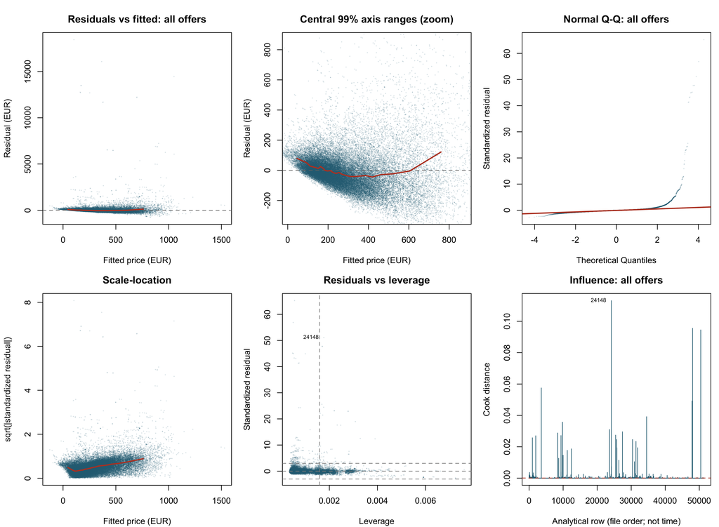

Figure 3. Preliminary OLS diagnostics (2 x 3 grid). Orange lines join mean residuals or mean scale-location values in equal-count fitted-value bins. The central view only zooms the display. Dashed leverage and Cook thresholds are screening rules, not deletion rules.

Table 9. Diagnostic screening summaries; thresholds flag observations for investigation, not automatic deletion.

| metric | value |
| --- | --- |
| Minimum fitted price | -125.648 |
| Maximum fitted price | 1529.391 |
| Negative fitted prices | 195.000 |
| Minimum residual | -752.060 |
| Maximum residual | 18442.454 |
| Maximum absolute studentized residual | 68.137 |
| Absolute externally studentized residual > 3 | 261.000 |
| Maximum leverage | 0.008 |
| Leverage > 2p/n | 4520.000 |
| Maximum Cook distance | 0.113 |
| Cook distance > 4/n | 615.000 |
| Cook distance > 1 | 0.000 |
| Largest/smallest fitted-decile residual SD | 6.500 |

Table 10. Ten offers with largest Cook distances, identified by source file and source row. These are provenance labels, not listing identifiers.

| analysis_row | source_file | source_row_index | city | day_type | room_type | realSum | fitted | residual | studentized_residual | leverage | cooks_distance |
| --- | --- | --- | --- | --- | --- | --- | --- | --- | --- | --- | --- |
| 24148 | london_weekdays.csv | 1886 | london | weekdays | Entire home/apt | 15499.89 | 1050.828 | 14449.066 | 52.508 | 0.002 | 0.113 |
| 48030 | vienna_weekdays.csv | 210 | vienna | weekdays | Private room | 13664.31 | 171.578 | 13492.728 | 48.863 | 0.002 | 0.096 |
| 50429 | vienna_weekends.csv | 879 | vienna | weekends | Private room | 13656.36 | 169.485 | 13486.874 | 48.841 | 0.002 | 0.095 |
| 3577 | athens_weekdays.csv | 1510 | athens | weekdays | Entire home/apt | 18545.45 | 102.997 | 18442.454 | 68.137 | 0.001 | 0.058 |
| 47866 | vienna_weekdays.csv | 45 | vienna | weekdays | Entire home/apt | 12942.99 | 252.871 | 12690.120 | 45.817 | 0.001 | 0.049 |
| 34524 | paris_weekdays.csv | 2348 | paris | weekdays | Entire home/apt | 16445.62 | 365.838 | 16079.777 | 58.772 | 0.000 | 0.039 |
| 9785 | barcelona_weekends.csv | 898 | barcelona | weekends | Entire home/apt | 6942.77 | 473.435 | 6469.335 | 23.032 | 0.003 | 0.036 |
| 9786 | barcelona_weekends.csv | 899 | barcelona | weekends | Entire home/apt | 6942.77 | 473.433 | 6469.337 | 23.032 | 0.003 | 0.036 |
| 23642 | london_weekdays.csv | 1378 | london | weekdays | Private room | 12076.95 | 379.591 | 11697.363 | 42.097 | 0.001 | 0.031 |
| 27420 | london_weekends.csv | 562 | london | weekends | Private room | 12048.73 | 376.768 | 11671.964 | 42.002 | 0.001 | 0.030 |

## 5.1 Supplementary mean-function and spatial checks

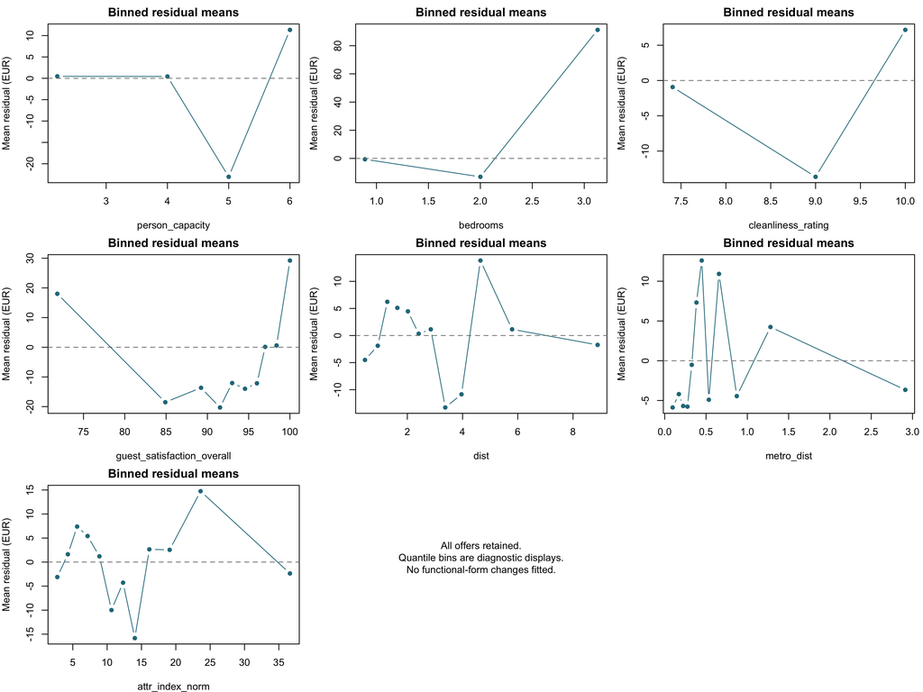

Figure 4. Residual means across empirical quantile bins of each numerical predictor. Values at identical predictor levels are kept together. Systematic departures from zero suggest unmodeled mean structure; these descriptive bins do not isolate a new partial effect.

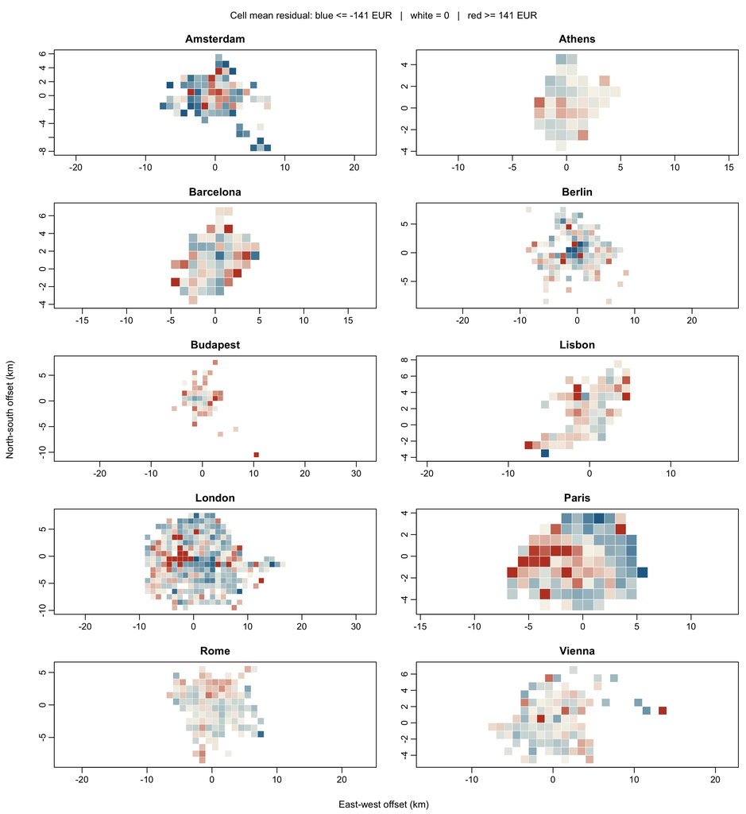

Figure 5. Descriptive residual maps: mean residual in approximate 1 km cells with at least five offers. Colors saturate at the pooled 95th percentile of absolute displayed cell means; values are not truncated in the exported table. Local coordinates are city-centered. Spatial patterns may reflect omitted location structure; this is not a formal independence test.

## 5.2 Conclusions about assumptions

1. **Conditional mean / linearity:** Use Figure 3’s central view and Figure 4’s residual means to judge systematic departures from zero. Fitted-decile mean residuals range from EUR -37.76 to EUR 57.57, indicating that the pooled linear mean structure is incomplete. Residual orthogonality to included columns does not establish that the conditional mean is correctly specified.
2. **Constant error variance:** The scale-location pattern and unequal residual dispersion raise concerns about homoskedasticity. The largest/smallest fitted-decile residual-SD ratio is 6.50. This is descriptive evidence, not a formal variance-test p-value.
3. **Normal errors / tails:** The full-range Q-Q plot has a pronounced upper-tail departure. The largest absolute externally studentized residual is 68.14; 261 observations exceed 3 in absolute value. The normal-error approximation is poor, and influential tails also complicate large-sample inference. No Shapiro-Wilk test is used.
4. **Outliers, leverage, and influence:** There are 4520 observations above the leverage screen $2p/n$, 615 above the Cook screen $4/n$, and 0 above Cook distance 1. Maximum Cook distance is 0.113. These are screening measures, not evidence that an offer is erroneous. Table 10 makes the most influential offers traceable; all are retained.
5. **Independence:** Not established and substantively doubtful. Figure 5 checks residual geography descriptively; localized patterns can reflect omitted location effects as well as dependence. Repeated properties or hosts may occur within/across samples, but no valid identifiers are supplied. File order is not time and cannot support a serial-independence test. City effects do not remove within-city spatial or within-host dependence. No formal independence conclusion follows from the residual grid.
6. **Estimability / collinearity:** The 41-column design has full rank 41, so no exact linear aliasing occurs. Correlations of numerical predictors are exported for inspection; full rank does not establish weak collinearity. Coefficients remain conditional on correlated controls and the chosen coding.

Consequently, the model supplies a preliminary adjusted point estimate, but its classical SEs, CIs, and p-values are **provisional**. A large sample and moderate R-squared do not resolve heteroskedasticity, dependence, mean misspecification, or unobserved sample-composition differences. Negative fitted prices, if present (195 here), are additional evidence of limitations of an additive raw-price model, not a reason to delete offers.

# 6 Context, interpretation, and next-stage plan

The controls represent the accommodation-size, quality, location, and host-scale dimensions motivated in the research plan. Room-type heterogeneity provides a reason to test the targeted interaction directly. However, seasonal heterogeneity in Voltes-Dorta and Sanchez-Medina (2020) does not establish a weekend effect; Abrate et al.’s (2022) longitudinal pricing-variability findings do not predict the sign of a portfolio coefficient in this price-level model. The original Gyodi and Nawaro (2021) study’s spatial emphasis makes the residual-location concerns salient. This is a methodological comparison using the supplied reading notes, not a completed full-paper synthesis or verified novelty claim.

The positive bedroom coefficient (EUR 81.00 per bedroom, conditional on capacity and other controls) is consistent with the size-related pricing motivation. In contrast, the city-center-distance coefficient is small (EUR -0.36 per km) and its conventional CI includes zero, while attraction accessibility has a positive coefficient. This should prompt examination of correlated location measures and functional form; it does not establish that location is unimportant. The 5+ portfolio coefficient is positive (EUR 25.09 versus single offers), but it describes price levels rather than the pricing variability studied by Abrate et al.

The estimated interaction concerns differences between **available-offer samples** in the sampled cities and collection periods. It is neither a common percentage premium nor evidence of within-property dynamic pricing. Observed covariates cannot remove unmeasured availability, date/event, or quality differences. The original collection dates and protocol must be checked before generalizing.

For the later stage, connect each proposed change to the diagnostics:

- Investigate source records for influential offers; do not remove them merely because they are expensive or influential. Assess sensitivity only with a documented substantive rationale.
- Assess nonlinear size, rating, and accessibility terms and whether the pooled slopes/common interaction are substantively defensible. A city-specific three-way interaction changes the common-contrast assumption and should be evaluated deliberately, with a clearly defined reporting target.
- Consider a log-price response or an alternative variance model if supported by conditional diagnostics. A log response changes the estimand and requires revised interpretation; a more symmetric marginal histogram is insufficient.
- Plan inference addressing heteroskedasticity and plausible spatial/repeated-host dependence. Heteroskedasticity-robust SEs alone do not solve dependence, and grouping by ten cities requires care. Valid identifiers would be needed for property/host matching or those cluster definitions.
- Reassess diagnostics after any later change and agree member responsibilities and dates using the actual later course deadlines. No team assignment or date is invented here.

No transformation, outlier exclusion, robust-SE replacement, weighting, spatial regression, or significance-driven term removal has been applied to this Part 1 fit.

# 7 Reproducibility and outputs

Run `Rscript part1_regression/analysis/render_part1.R` from the repository root (or `Rscript analysis/render_part1.R` from `part1_regression`), or knit this file in RStudio. In this VS Code workspace, use **Tasks: Run Build Task** and select **Render Part 1 R Markdown** to use the configured local R environment. Required packages are `rmarkdown` and `knitr`, plus Pandoc (included with RStudio). This report is self-contained HTML; raw data remain unchanged. All outputs are regenerated by the Rmd, including:

- `data/processed/part1_offers.csv`: cleaned analytical sample with provenance.
- `output/part1/preliminary_model.rds`: fitted R `lm` object.
- `output/part1/tables/`: complete summaries, cell counts, coefficients, contrasts, partial F-test, diagnostics, influential offers, and source-file checksums.
- `output/part1/figures/`: high-resolution PNGs for the report and proposal.
- `output/part1/session_info.txt`: R and package versions.

These figures and tables support proposal preparation; the proposal still needs its own selected, formatted displays, captions within section word limits, and the remaining required sections. R code and raw console output should not be copied into that written proposal.

# 8 References

Gyódi, K., & Nawaro, Ł. (2021). Determinants of Airbnb prices in European cities: A spatial econometrics approach. *Tourism Management, 86*, 104319. https://doi.org/10.1016/j.tourman.2021.104319

Gyódi, K., & Nawaro, Ł. (2021). *Determinants of Airbnb prices in European cities: A spatial econometrics approach (Supplementary Material)* [Data set]. Zenodo. https://doi.org/10.5281/zenodo.4446043. CC-BY-4.0. Original source names and attribution are preserved in the repository metadata.

Voltes-Dorta, A., & Sánchez-Medina, A. (2020). Drivers of Airbnb prices according to property/room type, season and location: A regression approach. *Journal of Hospitality and Tourism Management, 45*, 266-275. https://doi.org/10.1016/j.jhtm.2020.08.015

Abrate, G., Sainaghi, R., & Mauri, A. G. (2022). Dynamic pricing in Airbnb: Individual versus professional hosts. *Journal of Business Research, 141*, 191-199. https://doi.org/10.1016/j.jbusres.2021.12.012